# Women in tech meetups

2019-03-18

## Welcome

Welcome to today's [R-Ladies MTL session](https://github.com/rladies/meetup-presentations_montreal). As a passionate R-Lady, I feel incredibly connected to the community we're created here. Every month, we get to sit down, code, learn and share in an open and welcoming environment.

I get a lot out of these meetups. And you all keep coming, it means you do to. But I also wonder if we can see some macro level impacts of informal networking groups like this.

In today's session, I'll be presenting some data on women in tech groups (like this one) and wether there is evidence that they've had a impact on the lives of women in tech.

## Research question

Are women in tech groups associated with more women in the tech industry and greater pay equity: An ecological analysis

## Method

## Data sources

We collected data from several sources

- Meetup.com: RSVP all "women in tech" group events

  ```
  + Over 1 million meetup events from all over the world between
  2002 and 2019

  + Over 50k women in tech groups between 2002 to 2019
  ```

- Publicly avaialble global figures of women in tech, salaries, wage gaps

  ```
  + 41 countries, cross sectional.

  + Data collected from global reports, eurostat, OECD, UNESCO’s
  Institute for Statistics database, World Economic Forum Report, ILO,
  ILOSTAT database
  ```

## Download the data

[Click here for the data!](https://github.com/rladies/meetup-presentations_montreal/releases/download/20190321/data.zip)

## Scrape the meetup.com data

Package: Source: https://github.com/rladies/meetupr

Get API here: https://secure.meetup.com/meetup_api/key/

```r
Sys.setenv(MEETUP_KEY = "PASTE YOUR MEETUP KEY HERE")
# Slow function so we don't hit the Meetup rate limit From here:
# https://github.com/rladies/meetupr/issues/30#issuecomment-379900167
slowly <- function(f, delay = 0.25) {
    function(...) {
        Sys.sleep(delay)
        f(...)
    }
}
# Wrap 'get_events'' to link the parent group into the result data
get_group_events <- function(group) {
    events <- get_events(group, event_status = "past")
    events <- events %>% mutate(group_url = group)
}
```

## Classify "tech" meetups

| girls | biotech | python |
| --- | --- | --- |
| female | data mining | PHP |
| big data | analytics | swift |
| blockchain | nerd | ruby |
| machine learning | geek | web dev |
| artificial intelligence | code | webdev |
| virtual reality | develop | game dev |
| augmented reality | javascript | gamedev |
| biotech | html | unity |
| data mining | java | code |
| analytics | nerd | fintech |
| NA | geek | NA |

## Filtering tech groups

```r
# Fetch all groups matching the keywords above
fetch_results <- map(keywords, slowly(safely(find_groups)))

# meetupr returns a list with a result and error entry for each keyword
# We only want the results, so pull those out and bind them into one table
all_results <- fetch_results %>%
  map("result") %>%
  bind_rows()

# Filter tech groups, and unique (just in case)
unique_groups = all_results %>%
  select(id, name, urlname, created, members, status, city, state, country, who, organizer_id, organizer_name, category_id, category_name) %>%
  filter(category_name == "Tech") %>%
  distinct()

# Save results
write.csv(unique_groups, "groups.csv")
```

## Finding Events

```r
unique_groups <- read.csv("groups.csv")

# Split the requests into chunks in case we disconnect part way
chunk_size <- 100
number_chunks <- as.integer(nrow(unique_groups) / chunk_size) + 1

# Warning: This will take approximate 18 years
for (offset in 1:number_chunks) {
  start <- 1 + (offset * chunk_size)
  end <- (offset + 1) * chunk_size
  print(offset)

  # Get the groups in the current chunk
  group_urls <- unique_groups %>%
    select(urlname) %>%
    slice(start:end)

  # Request all the events for each group
  event_results <- map(group_urls$urlname, slowly(safely(get_group_events)))

  # Guard against the end of the list
  if (length(event_results) > 0) {
    filtered_results <- event_results %>%
      map("result") %>%
      bind_rows() %>%
      select(id, name, local_date, yes_rsvp_count, group_url)

    # Save our progress to disk in case we error out somewhere
    write_csv(filtered_results, path = "events.csv", append = TRUE)
  }
}
```

## Let's explore the data

| name | members | city | state | country | who | year |
| --- | --- | --- | --- | --- | --- | --- |
| Girl Develop It Boise | 549 | Boise | ID | US | Techies | 2014 |
| Girl Develop It West Palm Beach | 885 | West Palm Beach | FL | US | Nerdettes | 2014 |
| Girl Develop It Atlanta | 2645 | Atlanta | GA | US | Developers | 2014 |
| Girls in Tech - Los Angeles | 1062 | Santa Monica | CA | US | GITLA Techies | 2014 |
| Girl Develop It NYC | 14519 | New York | NY | US | Nerdettes | 2010 |
| Getting Girls to Code (Supporting Made with Code by Google) | 1624 | Sydney |  | AU | coders | 2014 |
| Girl Develop It Philadelphia | 5544 | Philadelphia | PA | US | students | 2011 |

## Women in tech groups over time

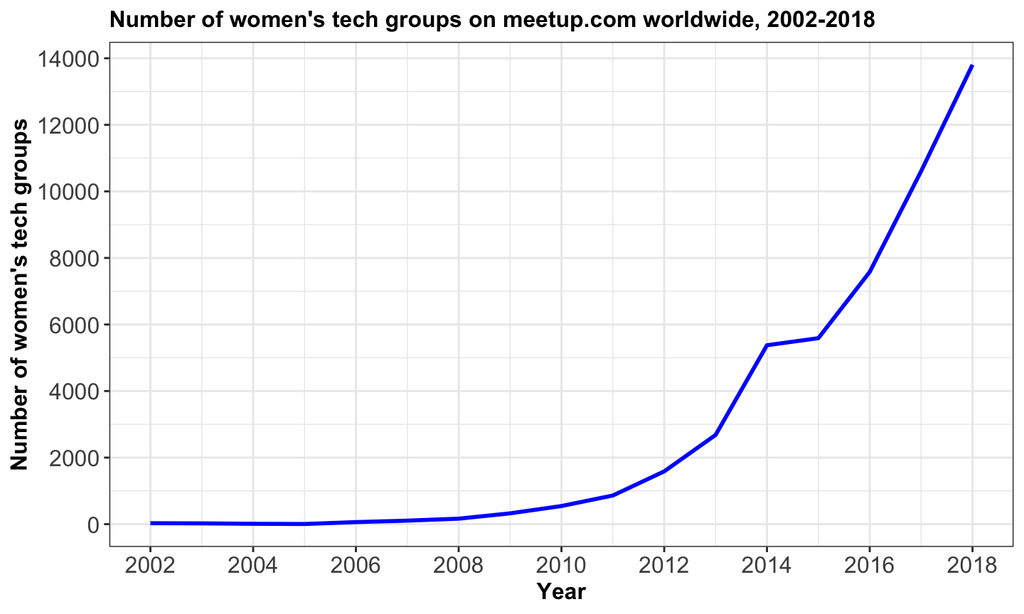

## R-Ladies over time

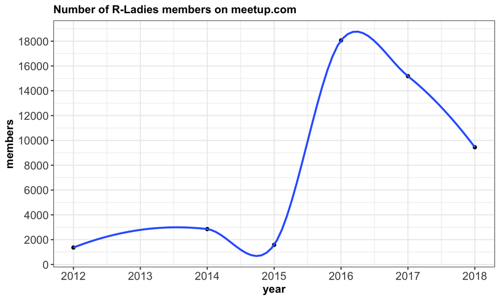

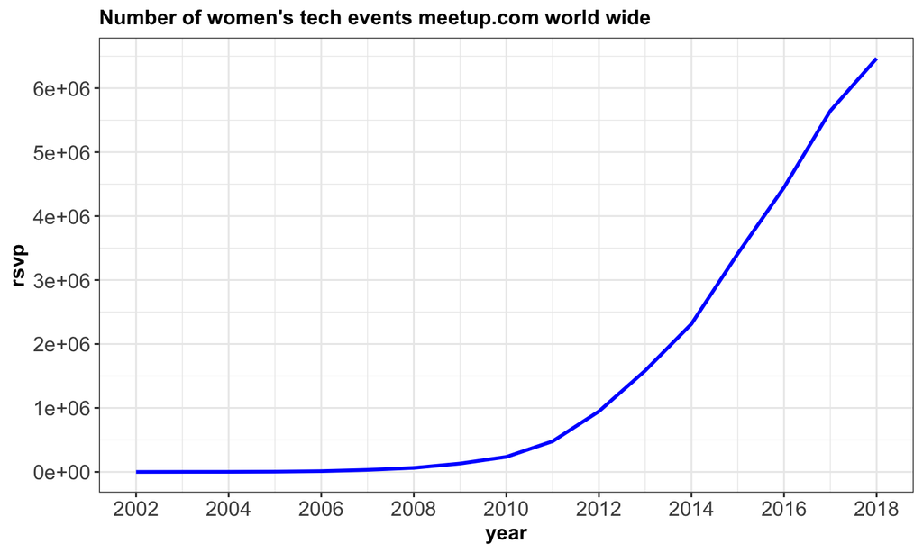

## Women in tech worldwide

source: https://www.honeypot.io/women-in-tech-2018/

Sub-major group 25 of the [International Standard Classification of Occupations (ISCO-08)](https://www.ilo.org/public/english/bureau/stat/isco/).

The main components of this section are publishing activities, including software publishing (division 58), motion picture and sound recording activities (division 59), radio and TV broadcasting and programming activities (division 60), telecommunications activities (division 61) and information technology activities (division 62) and other information service activities (division 63). Source: Eurostat.

## The tech community: globally

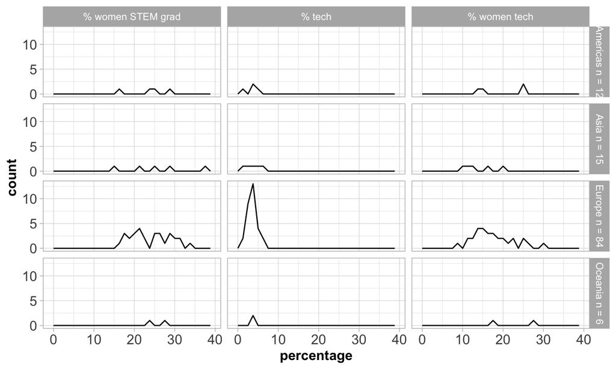

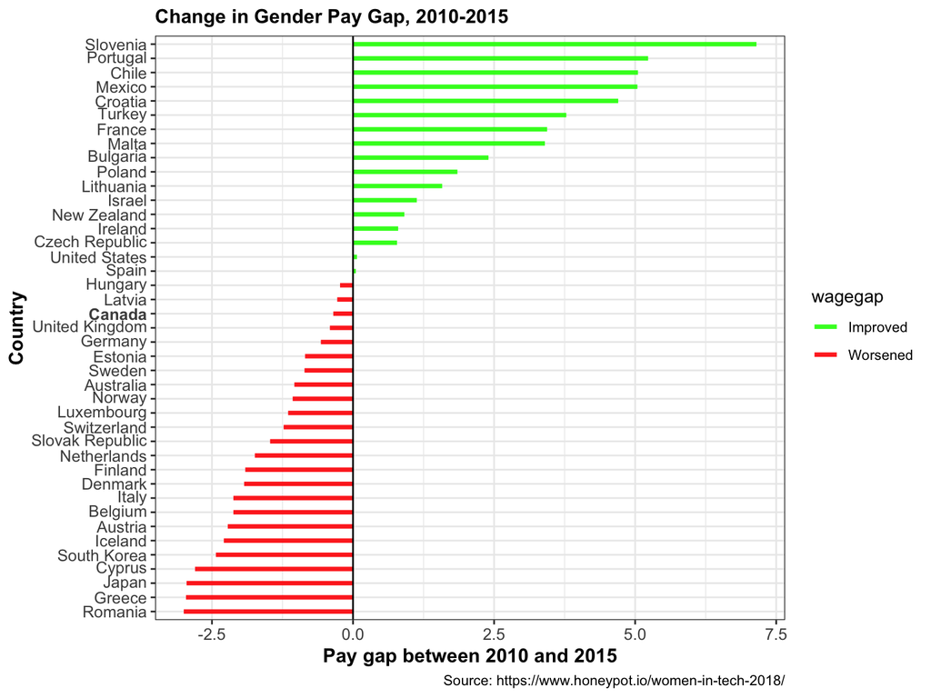

## Women in tech - stack overflow, globally

When making maps, sometimes you have data that has 2-character, 3-character abbreviations, full spelling. There's a handy package called `rworldmaps` that allows you to convert almost any geographic spelling to maps other types. See `?codelist` for all options.

```r
# Match country names in survey to the country names in package
matched = joinCountryData2Map(tech_jobs, joinCode="NAME", nameJoinColumn="country", verbose = T)
```

```
## 41 codes from your data successfully matched countries in the map
## 0 codes from your data failed to match with a country code in the map
##      failedCodes failedCountries
## 202 codes from the map weren't represented in your data
```

## Very ugly plot

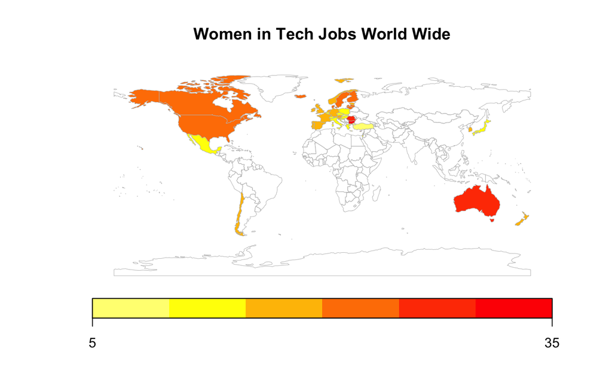

## Let's try to make it a bit prettier

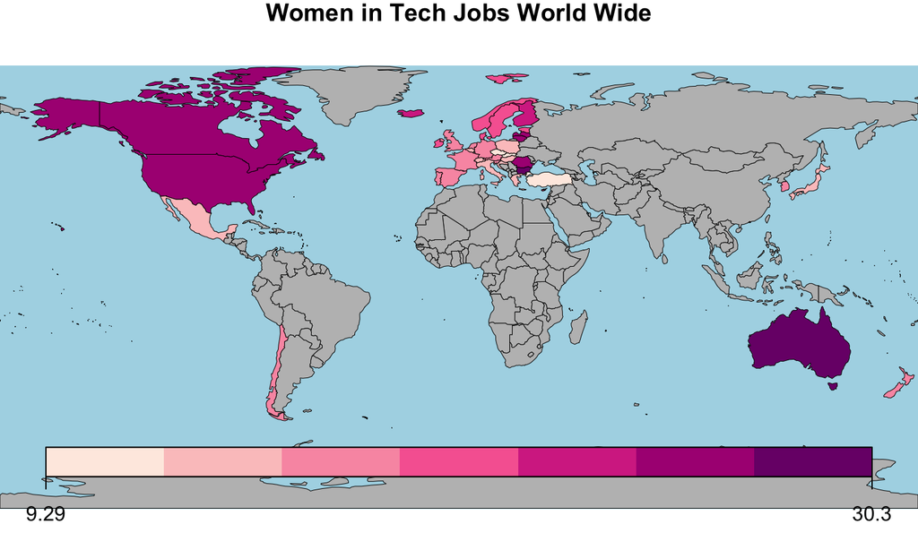

## Meetup tech groups and women in tech

Create a data frame of the number of groups, by year and country We'll only keep 2016 since the data for tech jobs is cross-sectional Convert the 2-letter ios2c country codes to full length country names Merge the tech jobs & meetup tech groups!

```r
groups_jobs = groups %>%
        filter(year == 2016) %>%
        group_by(country) %>%
        summarise(groups.total = n()) %>%
        rename(country.abb = country) %>%
        ungroup()

groups_jobs$country = countrycode(groups_jobs$country.abb, "iso2c", "country.name")

groups_jobs %<>%  left_join(tech_jobs) %>%
        na.omit() %>% data.frame()
```

## Create plot of jobs and tech groups

```r
plot.groups = ggplot(data = groups_jobs, aes(x = groups.total, y = tech_perc_women)) +
        geom_point() +
        geom_text_repel(aes(label=country.abb), size = 3) +
        labs(
                title = "Number of Women's Tech Groups and Women in Tech Jobs, by Country ",
                caption = "Source: https://www.honeypot.io/women-in-tech-2018/",
                x = "Women's Tech Meetup gGroups",
                y = "Percentage of women in tech") +
        guides(size = FALSE) +
        theme_bw() +
        theme(panel.grid.major.x = element_blank(),
        legend.position = 'none')
```

## Women's tech groups and jobs, by country

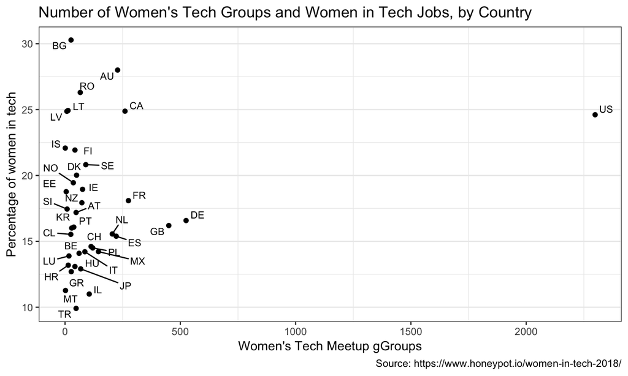

## Future directions

I'd like to keep exploring the data and wanted to ask for your help. It might be a fun idea to have a R-Ladies Montreal group analysis on … ourselves. All the code and data will be available on github. Please fork the repo and contribute in any way you'd like. The ultimate goal would be to write a short editorial and have it published in a journal.

So let's bounce some ideas around and see what we come up with!